# Final project --Chicago taxi project

## 1. Motivation

What's our dataset:

- Our dataset contains: All taxi trip information for Chicago in 2023, including time, location, trip fee and so on. The data is from [| City of Chicago | Data Portal](https://data.cityofchicago.org/Transportation/Taxi-Trips-2023/e55j-2ewb/about_data) (the size of dataset is 2.5GB). And weather data for Chicago throughout 2023, the url of which is https://www.wunderground.com/history/daily/us/il/chicago/KMDW.

Why did we choose these datasets:

- We want to provide Chicago taxi drivers with guidance about Where and when are there the most potential passengers, how severe weather affects people's travel frequency and methods, and so on. Therefore, we have chosen a year's worth of taxi trip data and weather conditions for data analysis, aiming to give detailed advice for different situations, such as the impact of different months, Day of the Week, hours, etc., on taxi driver turnover.

What is our goal for the end user's experience:

- We hope that the final visualization results are easy to understand and do their a favour, so that any Chicago taxi driver can use our website to guide them to find out what time, location, and weather conditions will help them pick up more passengers and earn more money.

## 2.Basic stats.

### 2.1 Our choices in data cleaning and preprocessing:

#### Import the library

```python
%pip install plotly

import numpy as np
import pandas as pd

import matplotlib.pyplot as plt
import matplotlib.patches as patches
import matplotlib.gridspec as gridspec
import matplotlib as mpl
import plotly.express as px
import plotly.graph_objects as go

import seaborn as sns

import dash
from dash import dcc, html
from dash.dependencies import Input, Output

import calmap
# import calplot
import calendar

import geopandas as gpd
from IPython.display import HTML
```

#### 2.1.1 Taxi dataset - Read and preprocessing

> **For taxi dataset**, we firstly listed all the characteristics of the dataset. Based on our needs, we filtered out Trip Start Timestamp, Trip Seconds, Trip Miles, Fare, Pickup/Dropoff Community Area, their latitude and longitude.

> According to the dataset description, we will have the missing value of the district which is out of the Chicago city. So we delete the rows which have the missing value.

> What's more, we make the boxplot of fares when we want to explore the relationship between fares and district/ time. Finally, we drew bar charts for different time dimensions.

```python
df = pd.read_csv('Taxi_Trips_-_2023_20240415.csv')
df.head(3)
```

|  | Trip ID | Taxi ID | Trip Start Timestamp | Trip End Timestamp | Trip Seconds | Trip Miles | Pickup Census Tract | Dropoff Census Tract | Pickup Community Area | Dropoff Community Area | ... | Extras | Trip Total | Payment Type | Company | Pickup Centroid Latitude | Pickup Centroid Longitude | Pickup Centroid Location | Dropoff Centroid Latitude | Dropoff Centroid Longitude | Dropoff Centroid Location |
| --- | --- | --- | --- | --- | --- | --- | --- | --- | --- | --- | --- | --- | --- | --- | --- | --- | --- | --- | --- | --- | --- |
| 0 | 0fca59218b11688279d795c03c4d16f851f13fa0 | e2c349c7cbb608d552aa0b5814031943f13641ef9e50d8... | 01/01/2023 12:00:00 AM | 01/01/2023 12:15:00 AM | 1037.0 | 4.82 | NaN | NaN | 6.0 | 32.0 | ... | 0.0 | 19.50 | Credit Card | Taxicab Insurance Agency Llc | 41.944227 | -87.655998 | POINT (-87.6559981815 41.9442266014) | 41.878866 | -87.625192 | POINT (-87.6251921424 41.8788655841) |
| 1 | 1e539d6e7501164c6b76b761c3152c235e206d59 | 4ab7a7510c1ebcc9b2e3eaa7bdd6508dbea34da7986aca... | 01/01/2023 12:00:00 AM | 01/01/2023 12:15:00 AM | 1341.0 | 16.63 | NaN | NaN | 76.0 | 8.0 | ... | 6.0 | 53.00 | Credit Card | Sun Taxi | 41.980264 | -87.913625 | POINT (-87.913624596 41.9802643146) | 41.899602 | -87.633308 | POINT (-87.6333080367 41.899602111) |
| 2 | 2b3c5200439d51f626b60380809bbbcca766a85b | 8c76eb82f069c0731a0049cb78898f02cc5ac6990244c9... | 01/01/2023 12:00:00 AM | 01/01/2023 12:15:00 AM | 844.0 | 3.84 | NaN | NaN | 24.0 | 8.0 | ... | 0.0 | 20.17 | Mobile | Sun Taxi | 41.901207 | -87.676356 | POINT (-87.6763559892 41.9012069941) | 41.899602 | -87.633308 | POINT (-87.6333080367 41.899602111) |

3 rows × 23 columns

- Below is the description of the features of our taxi dataset:

| Column Name | Description | Type |
| --- | --- | --- |
| Trip Start Timestamp | When the trip started, rounded to the nearest 15 minutes. | Date & Time |
| Trip End Timestamp | When the trip ended, rounded to the nearest 15 minutes. | Date & Time |
| Trip Seconds | Time of the trip in seconds. | Number |
| Trip Miles | Distance of the trip in miles. | Number |
| Pickup Census Tract | The Census Tract where the trip began. For privacy, this Census Tract is not shown for some trips. | Plain Text |
| Dropoff Census Tract | The Census Tract where the trip ended. For privacy, this Census Tract is not shown for some trips. | Plain Text |
| Pickup Community Area | The Community Area where the trip began. This column will be blank for locations outside Chicago. | Number |
| Dropoff Community Area | The Community Area where the trip ended. This column will be blank for locations outside Chicago. | Number |
| Fare | The fare for the trip. | Number |
| Tips | The tip for the trip. Cash tips generally will not be recorded. | Number |
| Tolls | The tolls for the trip. | Number |
| Extras | Extra charges for the trip. | Number |
| Trip Total | Total cost of the trip, the total of the previous columns. | Number |
| Payment Type | Type of payment for the trip. | Plain Text |
| Company | The taxi company. | Plain Text |
| Pickup Centroid Latitude | The latitude of the center of the pickup census tract or the community area if the census tract has been hidden. | Number |
| Pickup Centroid Longitude | The longitude of the center of the pickup census tract or the community area if the census tract has been hidden. | Number |
| Pickup Centroid Location | The location of the center of the pickup census tract or the community area if the census tract has been hidden. | Point |
| Dropoff Centroid Latitude | The latitude of the center of the dropoff census tract or the community area if the census tract has been hidden. | Number |
| Dropoff Centroid Longitude | The longitude of the center of the dropoff census tract or the community area if the census tract has been hidden. | Number |
| Dropoff Centroid Location | The location of the center of the dropoff census tract or the community area if the census tract has been hidden. | Point |

```python
df = df.drop(['Trip ID', 'Taxi ID', 'Trip End Timestamp','Payment Type','Company','Pickup Centroid Location','Dropoff Centroid  Location','Pickup Census Tract','Dropoff Census Tract'], axis=1)

# delete rows containing the Nan
df = df.dropna(subset=['Pickup Community Area','Dropoff Community Area'])
# transform the type into 'int'
df['Pickup Community Area'] = df['Pickup Community Area'].astype(int)
df['Dropoff Community Area'] = df['Dropoff Community Area'].astype(int)
df.head(3)
```

|  | Trip Start Timestamp | Trip Seconds | Trip Miles | Pickup Community Area | Dropoff Community Area | Fare | Tips | Tolls | Extras | Trip Total | Pickup Centroid Latitude | Pickup Centroid Longitude | Dropoff Centroid Latitude | Dropoff Centroid Longitude |
| --- | --- | --- | --- | --- | --- | --- | --- | --- | --- | --- | --- | --- | --- | --- |
| 0 | 01/01/2023 12:00:00 AM | 1037.0 | 4.82 | 6 | 32 | 15.75 | 3.25 | 0.0 | 0.0 | 19.50 | 41.944227 | -87.655998 | 41.878866 | -87.625192 |
| 1 | 01/01/2023 12:00:00 AM | 1341.0 | 16.63 | 76 | 8 | 41.50 | 5.00 | 0.0 | 6.0 | 53.00 | 41.980264 | -87.913625 | 41.899602 | -87.633308 |
| 2 | 01/01/2023 12:00:00 AM | 844.0 | 3.84 | 24 | 8 | 16.14 | 4.03 | 0.0 | 0.0 | 20.17 | 41.901207 | -87.676356 | 41.899602 | -87.633308 |

- Below we match the community number with the community name one-to-one

```python
# Create a dictionary to store park data
community = {
    1: "Rogers Park",
    2: "West Ridge",
    3: "Uptown",
    4: "Lincoln Square",
    5: "North Center",
    6: "Lake View",
    7: "Lincoln Park",
    8: "Near North Side",
    9: "Edison Park",
    10: "Norwood Park",
    11: "Jefferson Park",
    12: "Forest Glen",
    13: "North Park",
    14: "Albany Park",
    15: "Portage Park",
    16: "Irving Park",
    17: "Dunning",
    18: "Montclare",
    19: "Belmont Cragin",
    20: "Hermosa",
    21: "Avondale",
    22: "Logan Square",
    23: "Humboldt Park",
    24: "West Town",
    25: "Austin",
    26: "West Garfield Park",
    27: "East Garfield Park",
    28: "Near West Side",
    29: "North Lawndale",
    30: "South Lawndale",
    31: "Lower West Side",
    32: "Loop",
    33: "Near South Side",
    34: "Armour Square",
    35: "Douglas",
    36: "Oakland",
    37: "Fuller Park",
    38: "Grand Boulevard",
    39: "Kenwood",
    40: "Washington Park",
    41: "Hyde Park",
    42: "Woodlawn",
    43: "South Shore",
    44: "Chatham",
    45: "Avalon Park",
    46: "South Chicago",
    47: "Burnside",
    48: "Calumet Heights",
    49: "Roseland",
    50: "Pullman",
    51: "South Deering",
    52: "East Side",
    53: "West Pullman",
    54: "Riverdale",
    55: "Hegewisch",
    56: "Garfield Ridge",
    57: "Archer Heights",
    58: "Brighton Park",
    59: "Mckinley Park",
    60: "Bridgeport",
    61: "New City",
    62: "West Elsdon",
    63: "Gage Park",
    64: "Clearing",
    65: "West Lawn",
    66: "Chicago Lawn",
    67: "West Englewood",
    68: "Englewood",
    69: "Greater Grand Crossing",
    70: "Ashburn",
    71: "Auburn Gresham",
    72: "Beverly",
    73: "Washington Heights",
    74: "Mount Greenwood",
    75: "Morgan Park",
    76: "Ohare",
    77: "Edgewater"
}
print(community)
```

```
{1: 'Rogers Park', 2: 'West Ridge', 3: 'Uptown', 4: 'Lincoln Square', 5: 'North Center', 6: 'Lake View', 7: 'Lincoln Park', 8: 'Near North Side', 9: 'Edison Park', 10: 'Norwood Park', 11: 'Jefferson Park', 12: 'Forest Glen', 13: 'North Park', 14: 'Albany Park', 15: 'Portage Park', 16: 'Irving Park',…
```

#### 2.1.2 Weather dataset - Read and preprocessing

> **For the weather dataset**, we first read the weather dataset and the desription of features of it. We get many different kinds of weather conditions such as Haze, Cloudy, Light Rain, Fog, Cloudy and so on. So we decided to divide them into three groups( **normal_weather_conditions, bad_weather_conditions, worse_weather_conditions**) which help us explore further.

```python
df2 = pd.read_csv('test.csv')
df2.head(3)
```

|  | Time | Temperature | Dew Point | Humidity | Wind | Wind Speed | Wind Gust | Pressure | Precip. | Condition | Date |
| --- | --- | --- | --- | --- | --- | --- | --- | --- | --- | --- | --- |
| 0 | 01:53:00 | 38 °F | 33 °F | 83 % | SE | 6 mph | 0 mph | 29.18 in | 0.0 in | Haze | 2023/1/1 |
| 1 | 02:07:00 | 38 °F | 33 °F | 83 % | SE | 7 mph | 0 mph | 29.18 in | 0.0 in | Haze | 2023/1/1 |
| 2 | 02:31:00 | 38 °F | 33 °F | 83 % | SE | 6 mph | 0 mph | 29.18 in | 0.0 in | Haze | 2023/1/1 |

- Below is the description of feature of weather dataset:

| Column Name | Description | Type |
| --- | --- | --- |
| Time | Time of record. | Object |
| Temperature | Temperatuer | Object |
| Dew Point | Time of the trip in seconds. | Object |
| Humidity | Record of humidity. | Object |
| Wind | Direction of wind | Object |
| Wind Speed | Speed of wind | Object |
| Wind Gust | Gust of wind | Object |
| Pressure | Rcord of pressure | Object |
| Precip. | Precip. | Object |
| Condition | Weather of condition | Object |
| Date | Date of record | Object |

```python
# Access the desired column by specifying its name
column_name = 'Condition'  # Replace 'column_name_here' with the actual column name
column_values = df2[column_name]

# Get the unique values of the column
unique_values = column_values.unique()

print(unique_values)
```

```
['Haze' 'Cloudy' 'Light Rain' 'Fog' 'Mostly Cloudy' 'Mist' 'Light Drizzle'
 'Rain' 'Heavy Rain' 'Thunder' 'Light Rain with Thunder' 'Patches of Fog'
 'Partly Cloudy' 'Light Snow' 'Fair' 'Cloudy / Windy'
 'Mostly Cloudy / Windy' 'Light Snow / Windy' 'Light Rain / Windy'
 'Wintry Mix' 'Snow / Windy' 'Snow' 'Wintry Mix / Windy'
 'Partly Cloudy / Windy' 'Fair / Windy' 'Snow and Sleet'
 'Light Snow and Sleet' 'Heavy Snow / Windy' 'Rain / Windy' 'T-Storm'
 'Heavy T-Storm' 'Drizzle' 'Light Drizzle / Windy' 'Heavy T-Storm / Windy'
 'Light Sleet' 'T-Storm / Windy' 'Thunder / Windy' 'Smoke'
 'Heavy Rain / Windy' 'Tornado' 'Thunder in the Vicinity'
 'Heavy Snow / Windy / Fog' 'Heavy Snow / Fog' 'Light Snow with Thunder']
```

- Count the number of each condition

```python
column_values = df2[column_name]

# Get the count of each unique value in the column
value_counts = column_values.value_counts()

print(value_counts)
```

```
Condition
Fair                        2725
Cloudy                      2517
Mostly Cloudy               2316
Partly Cloudy                735
Light Rain                   713
Light Snow                   499
Light Drizzle                195
Fog                          111
Mist                          86
Cloudy / Windy                86
Smoke                         84
Light Rain with Thunder       83
Rain                          66
Thunder                       56
Wintry Mix                    48
Mostly Cloudy / Windy         46
Light Snow / Windy            33
Light Rain / Windy            32
Heavy T-Storm                 27
Haze                          25
Fair / Windy                  22
T-Storm                       16
Heavy Rain                    16
Heavy T-Storm / Windy          9
Partly Cloudy / Windy          9
T-Storm / Windy                5
Wintry Mix / Windy             5
Snow                           5
Snow and Sleet                 4
Light Drizzle / Windy          4
Thunder in the Vicinity        3
Light Snow and Sleet           2
Drizzle                        2
Light Sleet                    2
Rain / Windy                   2
Thunder / Windy                2
Heavy Snow / Fog               2
Tornado                        2
Heavy Snow / Windy             1
Heavy Snow / Windy / Fog       1
Snow / Windy                   1
Heavy Rain / Windy             1
Patches of Fog                 1
Light Snow with Thunder        1
Name: count, dtype: int64
```

- Divide the weather into three groups and mark the weather level for each day.

```python
# Convert Date column to datetime format
df2['Date'] = pd.to_datetime(df2['Date'])
df2.set_index('Date', inplace=True)

# Define bad and worse weather conditions
bad_weather_conditions = ['Light Rain', 'Light Snow', 'Light Drizzle','Fog','Mist','Smoke','Light Rain with Thunder',
                          'Wintry Mix','Light Snow / Windy',
                          'Light Rain / Windy', 'Haze', 'T-Storm / Windy', 'Wintry Mix / Windy',
                          'Light Drizzle / Windy', 'Light Snow and Sleet',
                          'Light Sleet', 'Rain / Windy', 'Thunder / Windy',
                          'Snow / Windy' ,'Patches of Fog']

worse_weather_conditions = ['Rain','Thunder',
                          'Heavy Rain', 'Heavy T-Storm / Windy',
                          'Snow', 'Snow and Sleet', 'Thunder in the Vicinity',
                          'Drizzle', 'Heavy Snow / Fog', 'Tornado', 'Heavy Snow / Windy',
                          'Heavy Snow / Windy / Fog',  'Heavy Rain / Windy', 'Light Snow with Thunder']

# Filter rows with bad and worse weather conditions
bad_weather_df2 = df2[df2['Condition'].isin(bad_weather_conditions)]
worse_weather_df2 = df2[df2['Condition'].isin(worse_weather_conditions)]

# Group by date and count the occurrences of bad and worse weather conditions
bad_weather_count_by_date = bad_weather_df2.groupby('Date').size()
worse_weather_count_by_date = worse_weather_df2.groupby('Date').size()

# Filter dates where the count is ten or more for bad weather
bad_weather_days = bad_weather_count_by_date[bad_weather_count_by_date >= 10].index.sort_values()

# Filter dates where the count is three or more for worse weather
worse_weather_days = worse_weather_count_by_date[worse_weather_count_by_date >= 3].index.sort_values()

# Filter dates where the count is ten or more for bad weather, excluding worse weather days
bad_weather_days = bad_weather_count_by_date[(bad_weather_count_by_date >= 10) & (~bad_weather_count_by_date.index.isin(worse_weather_days))].index.sort_values()

# Convert the index of bad_weather_count_by_date to a DataFrame
bad_weather_days_df2 = pd.DataFrame(bad_weather_days, columns=['Date'])
worse_weather_days_df2 = pd.DataFrame(worse_weather_days, columns=['Date'])

# Add a new column indicating bad weather
bad_weather_days_df2['weather'] = 'bad'
worse_weather_days_df2['weather'] = 'worse'
merged_df2 = pd.concat([bad_weather_days_df2, worse_weather_days_df2])

# Sort the merged DataFrame by date sequence
merged_df2_sorted = merged_df2.sort_values(by='Date')

# Reset index to make the first column numerical
merged_df2_sorted.reset_index(drop=True, inplace=True)

# Create a DataFrame containing all dates of 2023
all_dates_2023 = pd.date_range(start='2023-01-01', end='2023-12-31', freq='D')
all_dates_df2 = pd.DataFrame({'Date': all_dates_2023})

# Merge the DataFrame containing all dates with the sorted merged DataFrame
merged_df2_complete = pd.merge(all_dates_df2, merged_df2_sorted, on='Date', how='left')

# Fill NaN values in the 'weather' column with 'normal'
merged_df2_complete['weather'].fillna('normal', inplace=True)

print(merged_df2_complete)
```

```
          Date weather
0   2023-01-01     bad
1   2023-01-02     bad
2   2023-01-03   worse
3   2023-01-04     bad
4   2023-01-05     bad
..         ...     ...
360 2023-12-27  normal
361 2023-12-28     bad
362 2023-12-29     bad
363 2023-12-30     bad
364 2023-12-31     bad

[365 rows x 2 columns]
```

- Now, we have already made the weather variable **merged_df2_complete**. We can use it to make the calmap plot.

### 2.2 A short section that discusses the dataset stats, containing key points/plots from our exploratory data analysis:

#### 2.2.1 Taxi dataset

```python
df['Trip Start Timestamp'] = pd.to_datetime(df['Trip Start Timestamp'])

# merge by hours
df_hour = df.groupby(df['Trip Start Timestamp'].dt.hour).size().reset_index(name='Count')

# merge by week
df_week = df.groupby(df['Trip Start Timestamp'].dt.dayofweek).size().reset_index(name='Count')
df_week['Day'] = ['Monday', 'Tuesday', 'Wednesday', 'Thursday', 'Friday', 'Saturday', 'Sunday']

# merge by month
df_month = df.groupby(df['Trip Start Timestamp'].dt.month).size().reset_index(name='Count')
```

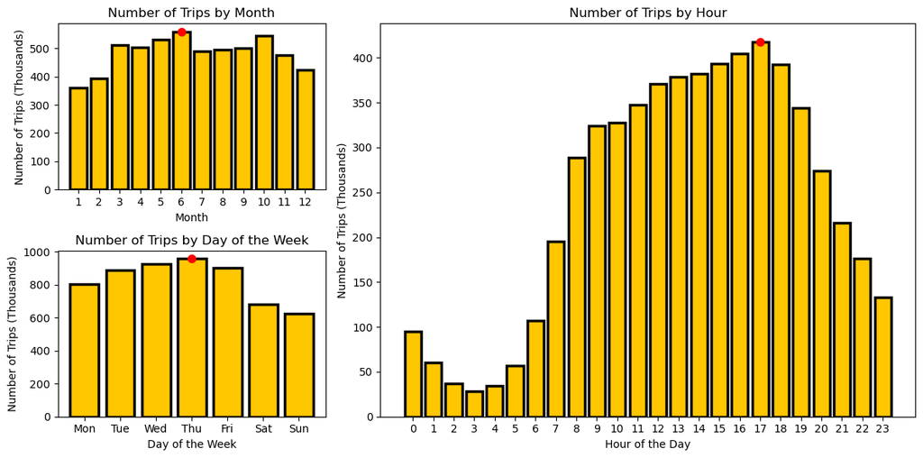

```python
# Create the canvas and gridspec layout
fig = plt.figure(figsize=(12, 6))
gs = gridspec.GridSpec(2, 2, figure=fig, width_ratios=[1, 2], height_ratios=[1, 1])

# Plot for month
ax1 = fig.add_subplot(gs[0, 0])
bars = ax1.bar(df_month['Trip Start Timestamp'], df_month['Count']/1000, color='#FFC700', edgecolor='black', linewidth=2.5, capstyle='round')
max_height = max(df_month['Count']/1000)  # Maximum height of bars
for bar in bars:
    if bar.get_height() == max_height:  # Mark red dot on the tallest bar
        ax1.scatter(bar.get_x() + bar.get_width() / 2, bar.get_height(), color='red', s=50, zorder=5)
ax1.set_xlabel('Month')
ax1.set_ylabel('Number of Trips (Thousands)')
ax1.set_title('Number of Trips by Month')
ax1.set_xticks(df_month['Trip Start Timestamp'])
ax1.set_xticklabels(df_month['Trip Start Timestamp'])

# Plot for week
ax2 = fig.add_subplot(gs[1, 0])
bars = ax2.bar(df_week['Trip Start Timestamp'], df_week['Count']/1000, color='#FFC700', edgecolor='black', linewidth=2.5, capstyle='round')
max_height = max(df_week['Count']/1000)  # Maximum height of bars
weekday_abbr = [calendar.day_abbr[i] for i in range(7)]
ax2.set_xticks(df_week['Trip Start Timestamp'])
ax2.set_xticklabels(weekday_abbr)
for bar in bars:
    if bar.get_height() == max_height:  # Mark red dot on the tallest bar
        ax2.scatter(bar.get_x() + bar.get_width() / 2, bar.get_height(), color='red', s=50, zorder=5)
ax2.set_xlabel('Day of the Week')
ax2.set_ylabel('Number of Trips (Thousands)')
ax2.set_title('Number of Trips by Day of the Week')

# Plot for hours
ax3 = fig.add_subplot(gs[:, 1])
bars = ax3.bar(df_hour['Trip Start Timestamp'], df_hour['Count']/1000, color='#FFC700', edgecolor='black', linewidth=2.5, capstyle='round')
max_height = max(df_hour['Count']/1000)  # Maximum height of bars
for bar in bars:
    if bar.get_height() == max_height:  # Mark red dot on the tallest bar
        ax3.scatter(bar.get_x() + bar.get_width() / 2, bar.get_height(), color='red', s=50, zorder=5)
ax3.set_xlabel('Hour of the Day')
ax3.set_ylabel('Number of Trips (Thousands)')
ax3.set_title('Number of Trips by Hour')
ax3.set_xticks(df_hour['Trip Start Timestamp'])
ax3.set_xticklabels(df_hour['Trip Start Timestamp'])

plt.tight_layout()
plt.show()
```

> From the perspective of **months**, we observe that the highest number occurs in June. From this monthly perspective, we contemplate whether the severity of weather in different months affects the number of orders. Therefore, we attempt to analyze from a weather standpoint, seeking to identify potential correlations between weather conditions and ride volume.

> From the perspective of **days**, we observe that Thursday has the highest number (with a significant decrease on weekends). However, we cannot derive much analysis solely from the days.

> From the perspective of **hours**, we observe that the number of taxi rides is concentrated in the afternoon (with the fewest orders occurring between 1:00 AM and 5:00 AM). Additionally, analyzing from an hourly standpoint is highly valuable. We attempt to explore the passenger flow at different times in various areas to provide some guidance for taxi drivers.

#### 2.2.2 Weather dataset

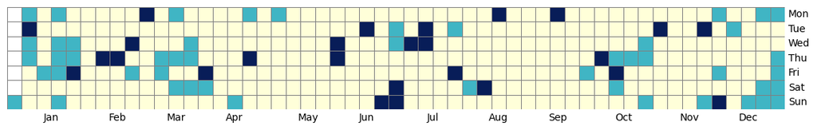

```python
# Read the CSV file into a DataFrame
df2 = pd.read_csv('test.csv')

# Convert Date column to datetime format and set as index
df2['Date'] = pd.to_datetime(df2['Date'])
df2.set_index('Date', inplace=True)

# Define bad and worse weather conditions
bad_weather_conditions = ['Light Rain', 'Light Snow', 'Light Drizzle', 'Fog', 'Mist', 'Smoke', 'Light Rain with Thunder',
                          'Wintry Mix', 'Light Snow / Windy', 'Light Rain / Windy', 'Haze', 'T-Storm / Windy',
                          'Wintry Mix / Windy', 'Light Drizzle / Windy', 'Light Snow and Sleet', 'Light Sleet',
                          'Rain / Windy', 'Thunder / Windy', 'Snow / Windy', 'Patches of Fog']

worse_weather_conditions = ['Rain', 'Thunder', 'Heavy Rain', 'Heavy T-Storm / Windy', 'Snow', 'Snow and Sleet',
                             'Thunder in the Vicinity', 'Drizzle', 'Heavy Snow / Fog', 'Tornado', 'Heavy Snow / Windy',
                             'Heavy Snow / Windy / Fog', 'Heavy Rain / Windy', 'Light Snow with Thunder']

# Filter rows with bad and worse weather conditions
bad_weather_df2 = df2[df2['Condition'].isin(bad_weather_conditions)]
worse_weather_df2 = df2[df2['Condition'].isin(worse_weather_conditions)]

# Group by date and count the occurrences of bad and worse weather conditions
bad_weather_count_by_date = bad_weather_df2.groupby('Date').size()
worse_weather_count_by_date = worse_weather_df2.groupby('Date').size()

# Filter dates where the count is ten or more for bad weather, excluding worse weather days
bad_weather_days = bad_weather_count_by_date[(bad_weather_count_by_date >= 10) &
                                             (~bad_weather_count_by_date.index.isin(worse_weather_count_by_date.index))]

# Convert the index of bad_weather_count_by_date to a DataFrame
bad_weather_days_df2 = pd.DataFrame({'Date': bad_weather_days.index, 'weather': 1})

# Filter dates where the count is three or more for worse weather
worse_weather_days = worse_weather_count_by_date[worse_weather_count_by_date >= 3]

# Convert the index of worse_weather_count_by_date to a DataFrame
worse_weather_days_df2 = pd.DataFrame({'Date': worse_weather_days.index, 'weather': 2})

# Merge the DataFrames
merged_df2 = pd.concat([bad_weather_days_df2, worse_weather_days_df2]).sort_values(by='Date')

# Create a DataFrame containing all dates of 2023
all_dates_2023 = pd.date_range(start='2023-01-01', end='2023-12-31')
all_dates_df2 = pd.DataFrame({'Date': all_dates_2023})

# Merge the DataFrame containing all dates with the sorted merged DataFrame
merged_df2_complete = pd.merge(all_dates_df2, merged_df2, on='Date', how='left')

# Fill NaN values in the 'weather' column with 'normal'
merged_df2_complete['weather'].fillna(0, inplace=True)

# Convert the 'Date' column to datetime format
merged_df2_complete['Date'] = pd.to_datetime(merged_df2_complete['Date'])

# Set the 'Date' column as the index
merged_df2_complete.set_index('Date', inplace=True)

precipitation = pd. Series (merged_df2_complete.weather)

# Set both index and column names to None
merged_df2_complete.index.name = None
merged_df2_complete.columns.name = None

# Plot the calmap
fig,ax = plt.subplots(figsize=(14,8))
calmap.yearplot(merged_df2_complete, cmap='YlGnBu', linewidth=0.5, edgecolor='gray')
```

- It's clear to see that there is more severe weather in June, July, and January, February, March.
- This fits well with the fact that the order volume is highest in June, but why are the orders still low in December, January, and February? We need to further explore, as it may not be directly related to the severity of the weather.

```python
merged_df2_complete.reset_index(level=0, inplace=True)
merged_df2_complete.rename(columns={'index': 'Date'}, inplace=True)
```

## 3. Data Analysis

Describe your data analysis and explain what you've learned about the dataset:

### 3.1 Plot all the communities

```python
gdf = gpd.read_file('Boundaries - Community Areas (current).geojson')
df['number'] = 1
```

```python
## divide Pickup Community Area and Dropoff Community Area
counts_pickup = df['Pickup Community Area'].value_counts()
data_pickup = counts_pickup.reset_index()
data_pickup.columns = ['Pickup Community Area', 'Counts']
data_pickup = pd.DataFrame(data_pickup)


counts_dropoff = df['Dropoff Community Area'].value_counts()
data_dropoff = counts_dropoff.reset_index()
data_dropoff.columns = ['Dropoff Community Area', 'Counts']
data_dropoff = pd.DataFrame(data_dropoff)
```

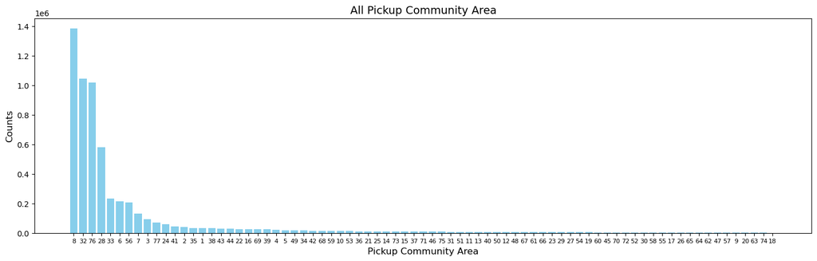

```python
data_pickup_sorted = data_pickup.sort_values('Counts', ascending=False)

plt.figure(figsize=(18, 5))
plt.bar(data_pickup_sorted['Pickup Community Area'].astype(str), data_pickup_sorted['Counts'], color='skyblue')
plt.title('All Pickup Community Area', fontsize=14)
plt.xlabel('Pickup Community Area', fontsize=12)
plt.ylabel('Counts', fontsize=12)
plt.xticks( fontsize=8)

plt.show()
```

> Based on the above chart, it can be observed that compared to the previous communities, the majority of communities have very few orders. To facilitate providing the optimal route recommendations, we choose to select the top 15 communities for further analysis.

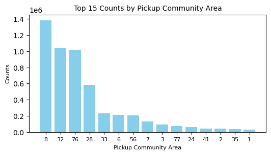

```python
# choose the top 15
data_pickup_15 = data_pickup_sorted.head(15)

plt.figure(figsize=(6, 3))
plt.bar(data_pickup_15['Pickup Community Area'].astype(str), data_pickup_15['Counts'], color='skyblue')
plt.title('Top 15 Counts by Pickup Community Area', fontsize=10)
plt.xlabel('Pickup Community Area', fontsize=8)
plt.ylabel('Counts', fontsize=8)
plt.xticks( fontsize=8)

plt.show()
```

> So we plot these top 15 communities with the highest passenger flow and observe their passenger flow changes within 24 hours.

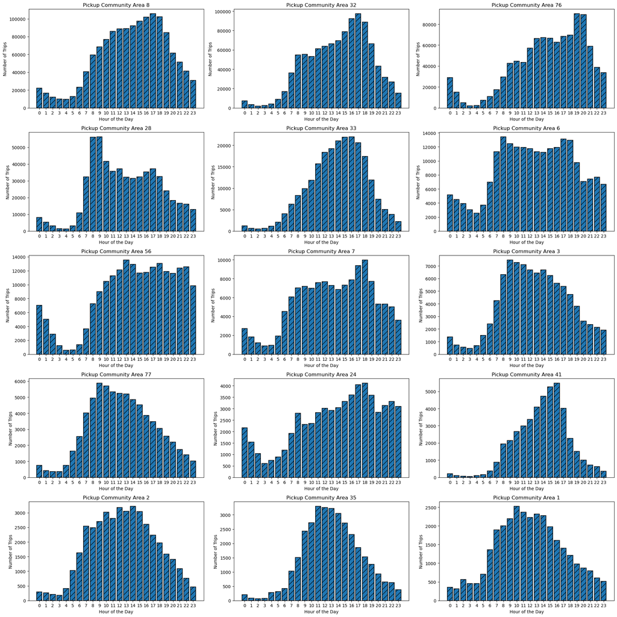

```python
first_15 = data_pickup_sorted["Pickup Community Area"].head(15)

df['Trip Start Timestamp'] = pd.to_datetime(df['Trip Start Timestamp'])

fig, axes = plt.subplots(nrows=5, ncols=3, figsize=(20, 20))
fig.subplots_adjust(hspace=0.5, wspace=0.5)

for i, ax in enumerate(axes.flatten()):
    if i < len(first_15):
        area = first_15.iloc[i]  # Use .iloc to access by position
        area_data = df.loc[df['Pickup Community Area'] == area]

        hourly_counts = area_data['Trip Start Timestamp'].dt.hour.value_counts().sort_index()

        hourly_counts = hourly_counts.reindex(range(24), fill_value=0)

        ax.bar(hourly_counts.index, hourly_counts.values, edgecolor='black', linewidth=1.2, capsize=5, ecolor='black', hatch='//', align='center')
        ax.set_title(f'Pickup Community Area {area}')
        ax.set_xlabel('Hour of the Day')
        ax.set_ylabel('Number of Trips')
        ax.set_xticks(range(24))
    else:
        ax.axis('off')

plt.tight_layout()
plt.show()
```

### 3.2 From pickup to dropoff communities

> We use the cross_tab to show the relationship between pickup communities and dropoff communities.

```python
cross_tab = pd.crosstab(df['Pickup Community Area'], df['Dropoff Community Area'])
print(cross_tab)
```

```
Dropoff Community Area    1      2      3      4      5      6      7
Pickup Community Area
1                       5492   2139   2317    860    193   1905   1030  \
2                       1877  10374   2148   1467    398   1880   1377
3                       2655   2567  20293   2117    906  10995   3222
4                        935   1531   1631   4674    547   1299    606
5                        224    386    628    519   2433   1980    733
...                      ...    ...    ...    ...    ...    ...    ...
73                        12      6     28      3     22     23     16
74                        48      1      2      0      0      7      1
75                         9      4     40      3      1     32     24
76                      8427   9661  18059  14466  20774  61577  55222
77                      2818   3086   7434   2036    469   5656   2113

Dropoff Community Area      8     9      10  ...   68   69   70   71   72
```

[output cut: 28 more lines]

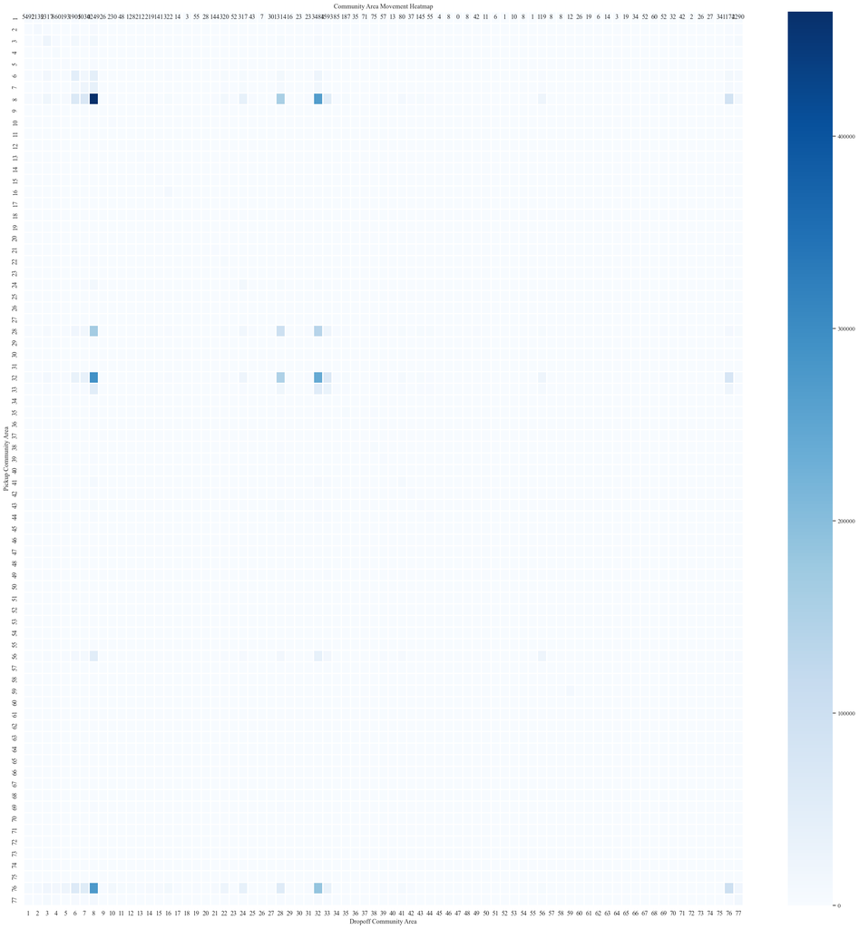

```python
# Set the overall style to 'whitegrid', which provides a grid background, making it look more formal for academic charts
sns.set(style="whitegrid")

# Set more refined font and size, more suitable for academic reports
mpl.rc('font', family='serif', serif='Times New Roman')
mpl.rcParams['font.size'] = 12  # Adjust font size as needed

# Use seaborn to plot the heatmap
plt.figure(figsize=(30, 30))
ax = sns.heatmap(cross_tab, annot=True, cmap='Blues', fmt='g', linewidths=1,)   # cbar_kws={'label': 'Number of Trips'}

plt.title('Community Area Movement Heatmap')
plt.xlabel('Dropoff Community Area')
plt.ylabel('Pickup Community Area')

# Adjust the font size of x-axis and y-axis tick labels
ax.tick_params(axis='x', labelsize=12)
ax.tick_params(axis='y', labelsize=12)

plt.show()
```

> We use the above heatmap to show which parts have more connections.

```python
# Fill missing values with 0 (simulating completeness of the actual cross_tab)
cross_tab = cross_tab.fillna(0)

# Extract values, row index, and column index from the cross_tab DataFrame and sort by values
flattened = cross_tab.stack().reset_index()
flattened.columns = ['Pickup Community Area', 'Dropoff Community Area', 'Trips']
sorted_flattened = flattened.sort_values(by='Trips', ascending=False)

# Display the sorted results and save to a new variable
sorted_flattened.reset_index(drop=True, inplace=True)

# Convert data type of all columns to int
sorted_flattened_int = sorted_flattened.astype(int)
sorted_flattened_int_200 = sorted_flattened_int.head(200)
sorted_flattened_int.head(200)
```

|  | Pickup Community Area | Dropoff Community Area | Trips |
| --- | --- | --- | --- |
| 0 | 8 | 8 | 464844 |
| 1 | 32 | 8 | 291722 |
| 2 | 76 | 8 | 274747 |
| 3 | 8 | 32 | 267673 |
| 4 | 32 | 32 | 241596 |
| ... | ... | ... | ... |
| 195 | 2 | 32 | 2562 |
| 196 | 32 | 69 | 2515 |
| 197 | 76 | 9 | 2511 |
| 198 | 6 | 1 | 2476 |
| 199 | 35 | 28 | 2450 |

200 rows × 3 columns

> Here, we explore the most common journeys, specifically focusing on their starting and ending locations.

> What's more, we observe which areas have more taxi orders and where passengers from these areas tend to travel more.

```python
# Calculate 1/3 of the length
one_third_length = int(len(sorted_flattened) / 3)

# Select the top 1/3 of the data
sorted_flattened_top_third = sorted_flattened.head(one_third_length)

# Convert data types to appropriate formats
sorted_flattened_top_third['Pickup Community Area'] = sorted_flattened_top_third['Pickup Community Area'].astype(str)
sorted_flattened_top_third['Dropoff Community Area'] = sorted_flattened_top_third['Dropoff Community Area'].astype(str)

# Create an interactive bar chart
fig = px.bar(sorted_flattened_top_third, x='Pickup Community Area', y='Trips',
             hover_data={'Dropoff Community Area': True, 'Trips': True},
             labels={'Trips': 'Trips', 'Pickup Community Area': 'Pickup Community Area',
                     'Dropoff Community Area': 'Dropoff Community Area'})

# Update the layout to enhance the display
fig.update_layout(title='Top One-Third Trips by Pickup and Dropoff Community Area',
                  xaxis_title='Pickup Community Area',
                  yaxis_title='Number of Trips',
                  hovermode='closest')

fig.show()
```

```python
# Create nodes for the Sankey diagram, where nodes represent the union of Pickup and Dropoff areas
all_areas = pd.concat([sorted_flattened_int_200['Pickup Community Area'], sorted_flattened_int_200['Dropoff Community Area']]).unique()
area_dict = {area: idx for idx, area in enumerate(all_areas)}

# Create links for the Sankey diagram, indicating flows from Pickup to Dropoff areas
links = {
    'source': sorted_flattened_int_200['Pickup Community Area'].map(area_dict),
    'target': sorted_flattened_int_200['Dropoff Community Area'].map(area_dict),
    'value': sorted_flattened_int_200['Trips']
}

# Create the Sankey diagram
fig = go.Figure(data=[go.Sankey(
    node=dict(
        pad=15,
        thickness=20,
        line=dict(color="black", width=0.5),
        label=[str(area) for area in all_areas]
    ),
    link=links
)])

# Update the layout for the Sankey diagram
fig.update_layout(font_size=10)
fig.show()
```

> Through the interactive bar chart and Sankey diagram, we will focus more on districts 8, 32, 76, 28, 33, 56 and so on. But the plots above are not readable enough for all the people. So we will do more explore on visualization part.

### 3.3 Box-plot with Trip fares

> In this part, we make the box-plots about fares

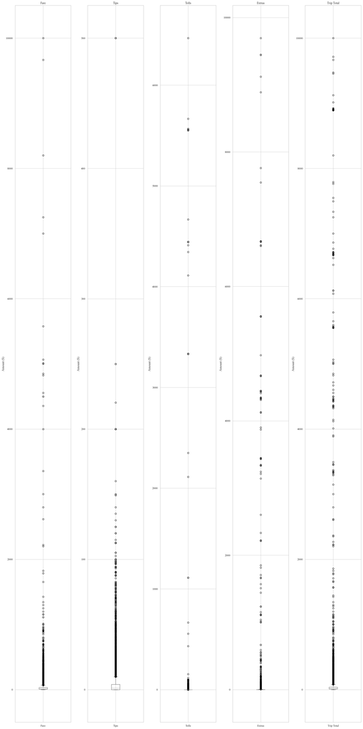

```python
fig, axes = plt.subplots(1, 5, figsize=(20, 40))

columns = ['Fare', 'Tips', 'Tolls', 'Extras', 'Trip Total']
for ax, column in zip(axes, columns):
    df.boxplot(column=column, ax=ax)
    ax.set_title(column)
    ax.set_ylabel('Amount ($)')

plt.tight_layout()
plt.show()
```

> Firstly, tips are not fully recorded (as cash payments are not logged), so they are not taken into account. Tolls cannot be considered as part of the driver's income, and "Extras" is not clearly explained. Additionally, from the box plot, it can be observed that the driver's actual income is mainly related to the Fare. Moreover, since we can obtain the fare standards from the official website, the longer the mile, the more objective the driver's profit. Therefore, we subsequently considered the "mile" variable.

### 3.4 Communities with the highest number of long-miles trips.

> Due to the varying number of orders in each area, we believe that **the median** can more accurately represent the information we need. So we calculated the median distance traveled for orders picked up from 77 pickup communities, sorted them by the median distance, and selected the top 15 medians.

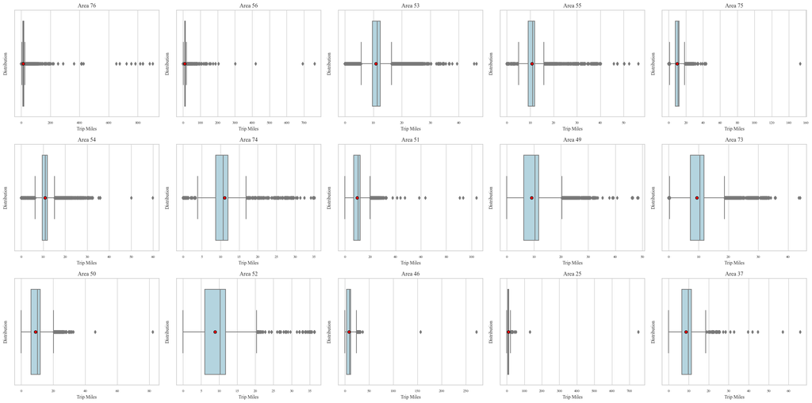

```python
# Calculate the median of Trip Miles for each area
median_miles = df.groupby('Pickup Community Area')['Trip Miles'].median().reset_index()

# Sort by median and select the top 10 areas with the highest median
top_areas = median_miles.sort_values(by='Trip Miles', ascending=False).head(15)

# Get data for these top 10 areas based on previous top_areas
top_area_data = df[df['Pickup Community Area'].isin(top_areas['Pickup Community Area'])]

# Create a subplot grid of 2 rows and 5 columns
fig, axes = plt.subplots(nrows=3, ncols=5, figsize=(24, 12))
axes = axes.flatten()  # Flatten for easier iteration

for i, area in enumerate(top_areas['Pickup Community Area']):
    area_data = top_area_data[top_area_data['Pickup Community Area'] == area]
    # Use Seaborn style to draw boxplots, with added functionality for fill color and displaying means
    sns.boxplot(ax=axes[i], x=area_data['Trip Miles'], color='lightblue', showmeans=True,
                meanprops={"marker":"o","markerfacecolor":"red", "markeredgecolor":"black"})
    axes[i].set_title(f'Area {area}', fontsize=12)
    axes[i].set_xlabel('Trip Miles', fontsize=10)
    axes[i].set_ylabel('Distribution', fontsize=10)
    axes[i].tick_params(axis='both', which='major', labelsize=8)

# Turn off axes for remaining subplots
for ax in axes[len(top_areas['Pickup Community Area']):]:
    ax.axis('off')

plt.tight_layout()
plt.show()
```

> We plan to further explore in the visualization section to ensure the ordered median number of trips for each hour which helps us get more useful information.

## 4. Genre

> We opted for a **magazine-style** approach. It's the most direct, allowing users to access information easily without needing to learn how to use it. Additionally, this format effectively communicates our data analysis and is relatively simple, allowing us to focus more on data analysis.

### 4.1 Which tools did we use from each of the 3 categories of Visual Narrative:

> **Visual Narrative**: We utilized a Consistent Visual Platform for Visual Structuring to enable users to freely and randomly browse the website. As the content is presented in parallel without any predefined chronological or hierarchical order.

> We also employed Zooming for Highlighting, particularly in the section on the impact of time on order quantity, enlarging the charts representing the most significant factor, "hour of day", to guide users to pay more attention and explore further. There's no Transition Guidance as our web page remains within one scene without involving scene or visual transitions.

### 4.2 Which tools did we use from each of the 3 categories of Narrative Structure:

> **Narrative Structure**: Our reading sequence is Random Access, allowing users to browse the website in any order they prefer. Our content without a specific chronological or hierarchical sequence, thus enabling users to independently choose the sections they are interested in browsing.

> For Interactivity, we employed Hover Details, Selection tools, and Explicit Instruction. This allows users to hover over data charts to view detailed information and select specific time periods to see corresponding order quantities. As we've emphasized, we aim for the website's operations to be simple, straightforward, and "idiot-proof," hence providing clear guidance upfront.

> For Messaging, we utilized Captions/Headlines to aid users in quickly understanding the content, Annotations to help users summarize information derived from charts, and introductory text at the beginning of the web page to introduce the main content, purpose, and simple usage instructions.

## 5. Visualizations

> Starting from the visualization section, we will use the names of communities in both images and texts instead of community IDs, which will enhance the readability of this part.

### 5.1 The variation of taxi trips data across time dimensions.

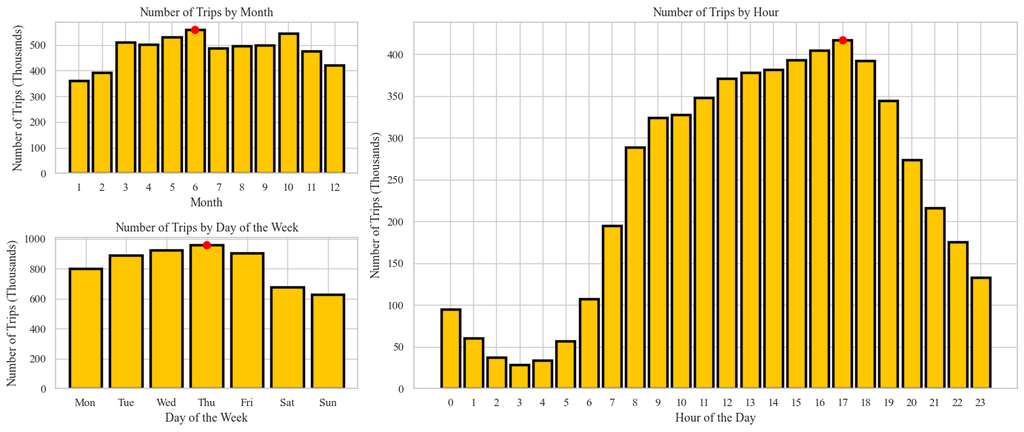

```python
# Create the canvas and gridspec layout
fig = plt.figure(figsize=(14, 6))
gs = gridspec.GridSpec(2, 2, figure=fig, width_ratios=[1, 2], height_ratios=[1, 1])

# Plot for month
ax1 = fig.add_subplot(gs[0, 0])
bars = ax1.bar(df_month['Trip Start Timestamp'], df_month['Count']/1000, color='#FFC700', edgecolor='black', linewidth=2.5, capstyle='round')
max_height = max(df_month['Count']/1000)  # Maximum height of bars
for bar in bars:
    if bar.get_height() == max_height:  # Mark red dot on the tallest bar
        ax1.scatter(bar.get_x() + bar.get_width() / 2, bar.get_height(), color='red', s=50, zorder=5)
ax1.set_xlabel('Month')
ax1.set_ylabel('Number of Trips (Thousands)')
ax1.set_title('Number of Trips by Month')
ax1.set_xticks(df_month['Trip Start Timestamp'])
ax1.set_xticklabels(df_month['Trip Start Timestamp'])

# Plot for week
ax2 = fig.add_subplot(gs[1, 0])
bars = ax2.bar(df_week['Trip Start Timestamp'], df_week['Count']/1000, color='#FFC700', edgecolor='black', linewidth=2.5, capstyle='round')
max_height = max(df_week['Count']/1000)  # Maximum height of bars
weekday_abbr = [calendar.day_abbr[i] for i in range(7)]
ax2.set_xticks(df_week['Trip Start Timestamp'])
ax2.set_xticklabels(weekday_abbr)
for bar in bars:
    if bar.get_height() == max_height:  # Mark red dot on the tallest bar
        ax2.scatter(bar.get_x() + bar.get_width() / 2, bar.get_height(), color='red', s=50, zorder=5)
ax2.set_xlabel('Day of the Week')
ax2.set_ylabel('Number of Trips (Thousands)')
ax2.set_title('Number of Trips by Day of the Week')

# Plot for hours
ax3 = fig.add_subplot(gs[:, 1])
bars = ax3.bar(df_hour['Trip Start Timestamp'], df_hour['Count']/1000, color='#FFC700', edgecolor='black', linewidth=2.5, capstyle='round')
max_height = max(df_hour['Count']/1000)  # Maximum height of bars
for bar in bars:
    if bar.get_height() == max_height:  # Mark red dot on the tallest bar
        ax3.scatter(bar.get_x() + bar.get_width() / 2, bar.get_height(), color='red', s=50, zorder=5)
ax3.set_xlabel('Hour of the Day')
ax3.set_ylabel('Number of Trips (Thousands)')
ax3.set_title('Number of Trips by Hour')
ax3.set_xticks(df_hour['Trip Start Timestamp'])
ax3.set_xticklabels(df_hour['Trip Start Timestamp'])

plt.tight_layout()
plt.show()
```

> This is the plot about the variation of taxi trips data across time dimensions. We choose it because we can read many basic information from it.

> Order volume is higher on weekdays compared to weekends. From Monday to Thursday, the number of orders shows an increasing trend, peaking on Thursday, and then starts to decline, reaching its lowest point on Sunday.

### 5.2 Scatter plot of changes in the number of pickups

**ATTENTION!!** **"You might not be able to see the following graph, but don't worry because I've deployed Dash on my local server when using Jupyter Notebook.You can't see it because you have no access to my local server. We have already deploy the dash on the external server(heroku), so you can see it on our website."**

```python
# Create Dash app
app1 = dash.Dash(__name__)

# App layout
app1.layout = html.Div([
    html.Div([
        dcc.Slider(
            id='hour-slider',
            min=0,
            max=23,
            value=0,  # Default value is 0
            marks={i: f'{i}' for i in range(24)},  # Marks from 0h to 23h, every hour
            step=1,  # Slider step is 1 hour
        ),
    ], style={'margin': '9px'}),
    html.Link(
        rel='stylesheet',
        href='style.css'
    ),
    dcc.Graph(id='map-graph')  # Graph
])#  ,style={'width': '600px', 'height': '400px'})  #   Adjust width and height here

# Callback function, update graph
@app1.callback(
    Output('map-graph', 'figure'),
    [Input('hour-slider', 'value')]
)
def update_map(selected_hour):
    df['Trip Start Timestamp'] = pd.to_datetime(df['Trip Start Timestamp'], errors='coerce')
    filtered_df = df[df['Trip Start Timestamp'].dt.hour == selected_hour]

    # Create map scatter plot
    fig = px.scatter_mapbox(filtered_df,
                           lat='Pickup Centroid Latitude',
                           lon='Pickup Centroid Longitude',
                           color_continuous_scale='Viridis',
                           mapbox_style='carto-positron',
                           zoom=9,
                           center={"lat": 41.8781, "lon": -87.6298},
                           opacity=0.5,
                           labels={'Population': 'Population Count'})
    fig.update_layout(height=800, width=800)
    return fig

# Run app
if __name__ == '__main__':
    app1.run_server(mode='inline', port=8050,debug=True)  # Run on local server, enable debug mode
```

[interactive chart not shown]

> The orders are concentrated in bustling coastal areas and around two airports. Orders are highly concentrated, meaning there is a significant difference in the number of orders between bustling and less busy areas.

Below is the bash deployed on the external server(heroku):

```python
HTML('<iframe src="https://socialdatadash1-61a56570ae3b.herokuapp.com" width="1000" height="600"></iframe>')
```

[interactive chart not shown]

### 5.3 Distribution plot of passenger flow in 15 communities.

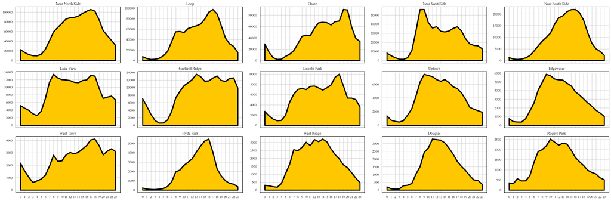

```python
fig, axes = plt.subplots(nrows=3, ncols=5, figsize=(27, 9))  # Adjust subplot layout as needed
axes = axes.flatten()

for i, ax in enumerate(axes):
    if i < len(first_15):
        area = first_15[i]
        area_data = df[df['Pickup Community Area'] == area].copy()  # Make a clear copy of the data

        area_data.loc[:, 'Trip Start Timestamp'] = pd.to_datetime(area_data['Trip Start Timestamp'])  # Use .loc to avoid SettingWithCopyWarning

        hourly_counts = area_data['Trip Start Timestamp'].dt.hour.value_counts().sort_index()

        # Plot the line graph
        ax.plot(hourly_counts.index, hourly_counts.values, color='black', linestyle='-', linewidth=3.5)

        # Fill the area under the line graph and add a black border to the filled area
        ax.fill_between(hourly_counts.index, hourly_counts.values, color='#FFC700', edgecolor='black', linewidth=3.5)

        # Use the community dictionary to replace area with its corresponding name
        ax.set_title(f'{community[area]}')

        # Set x-axis ticks
        ax.set_xticks(range(24))

        # Set the border color of the plot
        for spine in ax.spines.values():
            spine.set_edgecolor('black')

        # Remove x-axis labels and tick labels for the first and second rows
        if i < 10:  # Assuming there are 5 plots per row, and the first two rows have indices from 0 to 9
            ax.set_xlabel('')
            ax.set_xticklabels([])

    else:
        ax.axis('off')

# Adjust the spacing between subplots to be more compact
plt.subplots_adjust(hspace=0.3, wspace=0.1)  # Adjust the spacing parameters here as needed
plt.tight_layout()
plt.show()
```

### 5.4 MAP PLOT

```python
unique_areas = range(1, 79)
data_new = pd.DataFrame()

for area in unique_areas:
    temp_df = df[df['Pickup Community Area'] == area].head(1)
    if not temp_df.empty:
        data_new = pd.concat([data_new, temp_df], ignore_index=True)
data_new_selected = data_new[['Pickup Community Area','Pickup Centroid Latitude', 'Pickup Centroid Longitude']]

data_new_selected.rename(columns={'Pickup Community Area': 'Community Area',
                                   'Pickup Centroid Latitude': 'lat',
                                   'Pickup Centroid Longitude': 'lon'}, inplace=True)
data_new_selected.head(5)
```

|  | Community Area | lat | lon |
| --- | --- | --- | --- |
| 0 | 1 | 42.009623 | -87.670167 |
| 1 | 2 | 42.001571 | -87.695013 |
| 2 | 3 | 41.965812 | -87.655879 |
| 3 | 4 | 41.975171 | -87.687516 |
| 4 | 5 | 41.947792 | -87.683835 |

```python
# Merge the latitude and longitude for pickup areas
merged_data = sorted_flattened_int_200.merge(data_new_selected, how='left', left_on='Pickup Community Area', right_on='Community Area')
merged_data.rename(columns={'lat': 'pickup_lat', 'lon': 'pickup_lon'}, inplace=True)
merged_data.drop(columns=['Community Area'], inplace=True)  # Drop redundant columns

# Merge the latitude and longitude for dropoff areas
merged_data = merged_data.merge(data_new_selected, how='left', left_on='Dropoff Community Area', right_on='Community Area')
merged_data.rename(columns={'lat': 'dropoff_lat', 'lon': 'dropoff_lon'}, inplace=True)
merged_data.drop(columns=['Community Area'], inplace=True)  # Drop redundant columns

merged_data.head(3)
```

|  | Pickup Community Area | Dropoff Community Area | Trips | pickup_lat | pickup_lon | dropoff_lat | dropoff_lon |
| --- | --- | --- | --- | --- | --- | --- | --- |
| 0 | 8 | 8 | 464844 | 41.899602 | -87.633308 | 41.899602 | -87.633308 |
| 1 | 32 | 8 | 291722 | 41.878866 | -87.625192 | 41.899602 | -87.633308 |
| 2 | 76 | 8 | 274747 | 41.980264 | -87.913625 | 41.899602 | -87.633308 |

```python
# Create a color map where each Pickup Community Area has a different color
pickup_areas = merged_data['Pickup Community Area'].unique()
colors = px.colors.qualitative.Plotly  # Use Plotly's built-in colors
color_map = {area: colors[i % len(colors)] for i, area in enumerate(pickup_areas)}

# Create the figure object
fig = go.Figure()

# Plot the choropleth map
fig = px.choropleth_mapbox(data_pickup,
                           geojson=gdf,
                           locations='Pickup Community Area',  # Identifying column in the DataFrame
                           color='Counts',  # Map color based on counts
                           color_continuous_scale="Viridis",  # Color gradient scheme
                           featureidkey="properties.area_num_1",  # Ensure this matches the key in GeoJSON properties
                           mapbox_style="open-street-map",  # Map style
                           zoom=8,  # Map zoom level
                           center={"lat": 41.8781, "lon": -87.6298},  # Latitude and longitude of Chicago
                           opacity=0.5,  # Opacity of the map
                           labels={'Population': 'Count'},  # Custom label for color bar
                           range_color=(3000, 100000)  # Set color bar range
                          )

fig.update_traces(
    marker_line_width=2,
    marker_line_color='black',
)  # Add bold black borders

# Update layout to move the color bar to the left
fig.update_layout(coloraxis_colorbar=dict(
    title='Count',
    x=-0.1,  # x-coordinate of the color bar, negative value moves it to the left
    y=0.5,  # y-coordinate of the color bar, 0.5 places it in the middle
))

# Add lines for each trip with custom hover text
for i, row in merged_data.iterrows():
    fig.add_trace(go.Scattermapbox(
        mode = "lines",
        lon = [row['pickup_lon'], row['dropoff_lon']],
        lat = [row['pickup_lat'], row['dropoff_lat']],
        line = dict(width=max(min(row['Trips']/1000, 10), 1),
                    color=color_map[row['Pickup Community Area']]),
        opacity=max(min(row['Trips']/1000, 1), 0.1),
        text = f"From {community[row['Pickup Community Area']]}-{row['Pickup Community Area']} to {community[row['Dropoff Community Area']]}-{row['Dropoff Community Area']}",
        hoverinfo = "text",
        name = f"{community[row['Pickup Community Area']]}-{row['Pickup Community Area']} → {community[row['Dropoff Community Area']]}-{row['Dropoff Community Area']}"  # Set legend name
    ))

# Set map style
fig.update_layout(
    mapbox_style="carto-positron",
    mapbox=dict(
        center=dict(lon=-87.6298, lat=41.8781),
        zoom=10
    ),
    margin={"r":0,"t":0,"l":0,"b":0},
    legend_title_text='Trip Routes',  # Set legend title
    legend=dict(
        title_font=dict(size=12),  # Legend title font size
        orientation="v",  # Vertical legend placement
        x=1.05,  # Legend x-coordinate, outside the plot to the right
        xanchor="left",  # Anchor legend to the left
        y=0.5,  # Legend y-coordinate, centered
        yanchor="middle"  # Anchor legend to the middle
    )
)
fig.write_html("MAP_PLOT.html")
fig.show()
```

> A large number of taxi orders occur between core areas such as **Near North Side, Lincoln Park, Lake View, Uptown, Loop, Near South Side, and Near West Side**, which are adjacent communities. In addition, the main orders are from O'Hare airport to these core lakeside communities.

> Furthermore, combining this with the top 15 chart: Early morning in **Near North Side, Lake View, Lincoln Park, O'Hare. Rush hour in Near North Side, Loop, Near West Side**. Any location during noon and afternoon. Evening to night in **Near North Side, O'Hare, Loop, Near West Side, Garfield Ridge**. These areas have a relatively limited volume of orders at different times of the day. This also means that we need to stay as close as possible to these areas for activities.

### 5.5 The area with the highest number of large-miles trips.

```python
app2 = dash.Dash(__name__)

app2.layout = html.Div([
    dcc.Slider(
        id='hour-slider',
        min=0,
        max=23,
        value=12,
        marks={i: str(i) for i in range(24)},
        step=1,
    ),
    dcc.Graph(id='median-miles-graph')
])

@app2.callback(
    Output('median-miles-graph', 'figure'),
    Input('hour-slider', 'value')
)
def update_graph(selected_hour):
    # Filter the DataFrame for the selected hour
    filtered_df = df[df['Trip Start Timestamp'].dt.hour == selected_hour]

    # Calculate the median Trip Miles for each community area
    median_miles = filtered_df.groupby('Pickup Community Area')['Trip Miles'].median().reset_index()

    # Sort by median Trip Miles and select the top 14 areas
    top_areas = median_miles.sort_values(by='Trip Miles', ascending=False).head(14)

    # Create a new column combining the community area number and name
    top_areas['Community Info'] = top_areas['Pickup Community Area'].apply(
        lambda x: f"{x} - {community.get(x, 'Unknown')}"
    )

    # Create a line plot using the new column as x-axis labels
    fig = px.line(
        top_areas,
        x='Community Info',
        y='Trip Miles',
        line_shape='linear',  # Line shape: options are 'linear', 'spline', 'vhv', 'hvh', 'vh', 'hv'
        markers=True,  # Add markers
        labels={'Community Info': 'Community'}  # Customize axis labels
    )

    # Update the line style of the plot, changing the color to black
    fig.update_traces(line=dict(width=4, color="black"))

    # Add a yellow dashed line on the y-axis and label it "=15m"
    fig.add_shape(
        type='line',
        x0=0, x1=1,  # Range of the x-axis, represented in relative coordinates (0 for start, 1 for end)
        y0=15, y1=15,  # Position on the y-axis (fixed at 15 km)
        line=dict(
            color='#FFC700',
            width=2,  # Width of the dashed line
            dash='dash'  # 'dash' represents a dashed line
        ),
        xref='paper',  # Use 'paper' coordinate system (0~1)
        yref='y'  # Use the y-axis coordinates of the plot
    )

    # Add a new scatter plot, marking points where Trip Miles is greater than 15
    fig.add_scatter(
        x=top_areas[top_areas['Trip Miles'] > 15]['Community Info'],
        y=top_areas[top_areas['Trip Miles'] > 15]['Trip Miles'],
        mode='markers',
        marker=dict(size=10, color='#FFC700', symbol='circle'),  # Filled circle
        name='> 15 km'
    )

    return fig

if __name__ == '__main__':
    app2.run_server(mode='inline', port=8051,debug=True)
```

[interactive chart not shown]

> In the early hours of the morning, trips originating from South Chicago, Calumet Heights, Avalon Park, East Side, Lincoln Park, O'hare, Loop, Beverly, and Austin typically cover longer distances. Additionally, at other times, taxis departing from the O'Hare area travel the furthest, which is expected as it is near the airport. Garfield Ridge, on the other hand, ranks second in terms of trip distances for most of the day.

Below is the bash deployed on the external server(heroku):

```python
HTML('<iframe src="https://dash2-a606fc82305f.herokuapp.com" width="1000" height="600"></iframe>')
```

[interactive chart not shown]

### 5.6 The relationship between the number of trips and the weather

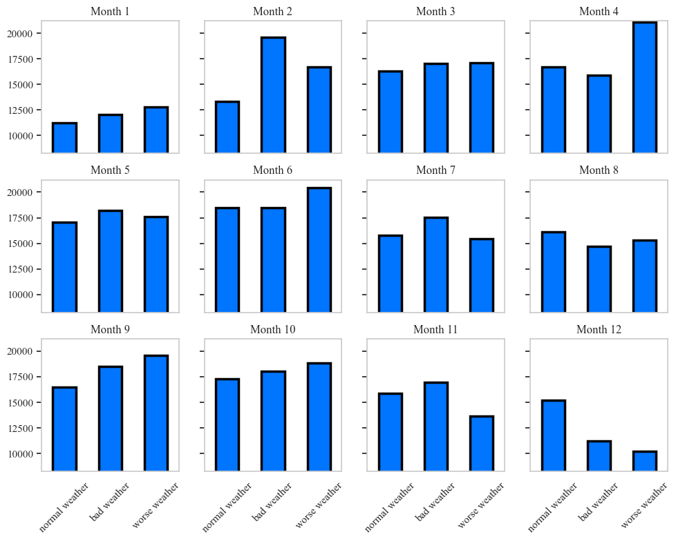

```python
df['Trip Start Timestamp'] = pd.to_datetime(df['Trip Start Timestamp'])
df_date = df.groupby(df['Trip Start Timestamp'].dt.date).size().reset_index(name='Count')
df_date['Trip Start Timestamp'] = pd.to_datetime(df_date['Trip Start Timestamp'])

order_merged_df2 = df_date.merge(merged_df2_complete, left_on='Trip Start Timestamp', right_on='Date', how='left')
# Convert 'Trip Start Timestamp' to datetime
order_merged_df2['Trip Start Timestamp'] = pd.to_datetime(order_merged_df2['Trip Start Timestamp'])

# Extract month
order_merged_df2['Month'] = order_merged_df2['Trip Start Timestamp'].dt.month

# Create 3x4 subplot grid
fig, axes = plt.subplots(3, 4, figsize=(10, 8))

# Initialize list to store all mean counts
all_monthly_means = []

weather_labels = ['normal weather', 'bad weather', 'worse weather']

# Iterate over each month
for month, ax in zip(range(1, 13), axes.flatten()):
    # Filter data for the current month
    monthly_data = order_merged_df2[order_merged_df2['Month'] == month]
    # Group by 'weather' and calculate mean of 'Counts'
    monthly_mean = monthly_data.groupby('weather')['Count'].mean()
    all_monthly_means.append(monthly_mean)
    # Plot the mean counts for each 'weather' condition
    bars = monthly_mean.plot(kind='bar', ax=ax, title=f'Month {month}', color='#0075FF', edgecolor='black', linewidth=2.5)
    # Remove grid lines
    ax.grid(False)

    # Set y-axis to display only tick marks and numerical labels
    ax.yaxis.set_ticks_position('left')
    ax.tick_params(axis='y', which='both', direction='out', length=5)  # Set tick marks to be outside

    # Set custom labels for the x-axis
    ax.set_xticks(range(len(weather_labels)))
    ax.set_xticklabels(weather_labels, rotation=45)

    # Set labels only on left column and bottom row
    if month % 4 != 1:  # Removes y-axis labels for all but the first column
        ax.set_yticklabels([])
    if month < 9:  # Removes x-axis labels for all but the bottom row
        ax.set_xticklabels([])
    ax.set_xlabel('')  # Remove x-axis labels
    ax.set_ylabel('')  # Remove y-axis labels

# Find the maximum and minimum values among all months
max_value = max([monthly_mean.max() for monthly_mean in all_monthly_means])
min_value = min([monthly_mean.min() for monthly_mean in all_monthly_means])

# Apply the maximum and minimum values to all subplots
for ax in axes.flatten():
    ax.set_ylim([min_value - 2000, max_value + 100])

plt.tight_layout()
plt.show()
```

> Special weather conditions may potentially increase the number of orders. however, this pattern is not always consistent.

> But at the same time, we believe that it might be more reasonable to explain this phenomenon by considering temperature. People may not have a strong desire to go out during the winter. Additionally, it's also possible that the harsh winter weather, such as heavy snowfall, makes it more difficult for people to accept.

## 6. Discussion

> **Smooth Progress**:
> - We successfully identified the patterns of taxi order fluctuations in various areas of Chicago, as well as the areas with the highest number of orders.
> - We analyzed the most common commuting routes between areas, assisting drivers in planning their waiting routes more effectively.
> - We explored the areas with the highest median mileage during different time periods, indicating that drivers in these areas often have higher earnings potential.
> - Our data provides intuitive guidance and analysis for drivers comprehensively.

> **Improvement**:
> - We lack data on the number of empty taxis in each area, making it difficult to calculate the ratio of taxi orders to empty taxis. This would provide better optimization and consider spatial-temporal allocation issues more effectively.
> - Regarding the impact of weather on order quantity, we only observed some trends but couldn't determine the exact influence. Therefore, further analysis on this aspect with stronger data support is needed.
> - Although we can analyze where the order volume is highest and provide driver recommendations, we didn't consider the information gap between passenger flow and taxi quantity in our analysis. In other words, a high order volume may also indicate greater competition among taxis.
> - If computational power and data allow, it would be beneficial to include data from 2022 and 2021. Analyzing only one year of data can lead to overfitting when analyzing seasonal variables, resulting in errors.
> - We used a magazine-style genre, which is straightforward and simple for presentation. However, it may reduce user initiative. In the future, we can work on enriching the interactivity of the website, such as adding buttons for playing animations.
> - The content we chose to display was derived from desktop research and brainstorming. However, this may not necessarily be the information that taxi drivers are most concerned about. Therefore, conducting surveys and usability tests in the future can help identify the information drivers are truly interested in and assess the rationality and user-friendliness of the website's interaction.

## 7. Contribution

> **Lin Zhu(s232291)** **1.** Search datasets **2.** Taxi dataset processing and viz **3.** The majority data analysis. **4.** Jupyter notebook and part of web

> **Yue Liu(s232190)** **1.** Design the plots and website **2.** Motivation and Genre part of the notebook. **3.** Part of data analysis

> **Kaizhi Fan(s240047)** **1.** Weather dataset preprocessing and viz **2.** deploy the server and develop the website

## 8. Reference

##### [1]:https://data.cityofchicago.org/Transportation/Taxi-Trips-2023/e55j-2ewb/about_data

##### [2]:https://www.wunderground.com/history/daily/us/il/chicago/KMDW

##### [3]:https://www.chicago.gov/content/dam/city/depts/doit/general/GIS/Chicago_Maps/Citywide_Maps/Community_Areas_W_Numbers.pdf